# EDA Assignment

Harshal Shah

February 16, 2019

## Introduction

The Gapminder Foundation was founded by Hans Rosling who is Professor of International Health at the Karolinska Institutet in Stockholm, Sweden. “The Best Stats You’ve Ever Seen” is a famous TedTalk lecture given by Hans Rosling. To help him visualise his talk, the team at Gapminder conputed animation with bubble charts, also knows as motion charts. By increase use of statistics and understading the other factors like economic,social, environmental development, Gapminder foundation enhances overall development. TrendAnalyzer is a data visulization software which was developed by Gapminder and then later acquired by Google Inc. in 2007.

## Data Description

The Data consists of 6 columns and 41284 rows. The six columns are 6 variables and 41284 observations. This data consists of variables country,year,income,life,population,region. Country represents all the countries. Year represents data from years 1800 to 2015. The regions included are America,East ASia and Pacific, Europe and Central Asia, Middle East and North Africa,South Asia,Sub-Saharan Africa. It appears that this data has been merged from different datasets. The code, output files and the plots can also be found on my github account by clicking the link https://github.com/harshalshahg/Dataanalytics/tree/master/Code

## Question 1: Examine usual life expectancy for different years.

```r
library(lattice)
library(plyr)
library(xtable)
library(dplyr)
```

```r
library(ggplot2)
library(gridExtra)
library(reshape2)
library(ggthemes)
library(scales)
```

#### Importing the file

```r
ds<- read.csv('C:/Users/harshal/Documents/homework/506/gapminder.csv',header = T)
summary(ds)
```

```
##                 Country           Year           life
##  Afghanistan        :  216   Min.   :1800   Min.   : 1.00
##  Albania            :  216   1st Qu.:1854   1st Qu.:31.00
##  Algeria            :  216   Median :1908   Median :35.12
##  Angola             :  216   Mean   :1907   Mean   :42.88
##  Antigua and Barbuda:  216   3rd Qu.:1962   3rd Qu.:55.60
##  Argentina          :  216   Max.   :2015   Max.   :84.10
##  (Other)            :39988
##    population        income                              region
##         :25817   Min.   :   142   America                   : 7961
##  121000 :    6   1st Qu.:   883   East Asia & Pacific       : 6256
##  14092  :    6   Median :  1450   Europe & Central Asia     :10468
##  1432000:    6   Mean   :  4571   Middle East & North Africa: 4309
##  229000 :    6   3rd Qu.:  3483   South Asia                : 1728
##  2574000:    6   Max.   :182668   Sub-Saharan Africa        :10562
##  (Other):15437   NA's   :2341
```

```r
 head(ds)
```

```
##       Country Year     life population income     region
## 1 Afghanistan 1800 28.21100    3280000    603 South Asia
## 2 Afghanistan 1801 28.20075               603 South Asia
## 3 Afghanistan 1802 28.19051               603 South Asia
## 4 Afghanistan 1803 28.18026               603 South Asia
## 5 Afghanistan 1804 28.17001               603 South Asia
## 6 Afghanistan 1805 28.15977               603 South Asia
```

```r
 str(ds) ## This tells us there are 41284 observables and 6 variables. This also tells us that there are blank values in population.
```

```
## 'data.frame':    41284 obs. of  6 variables:
##  $ Country   : Factor w/ 197 levels "Ãland","Afghanistan",..: 2 2 2 2 2 2 2 2 2 2 ...
##  $ Year      : int  1800 1801 1802 1803 1804 1805 1806 1807 1808 1809 ...
##  $ life      : num  28.2 28.2 28.2 28.2 28.2 ...
##  $ population: Factor w/ 15260 levels "","1,005,328,574",..: 7490 1 1 1 1 1 1 1 1 1 ...
##  $ income    : num  603 603 603 603 603 603 603 603 603 603 ...
##  $ region    : Factor w/ 6 levels "America","East Asia & Pacific",..: 5 5 5 5 5 5 5 5 5 5 ...
```

#### Reordering the columns in the dataframe so that related columns appear first

```r
## Reordering the columns in the dataframe so that related columns appear first
ds = ds[c('Country', 'region', 'Year',
                          'income', 'life',
                          'population')]
head(ds)
```

```
##       Country     region Year income     life population
## 1 Afghanistan South Asia 1800    603 28.21100    3280000
## 2 Afghanistan South Asia 1801    603 28.20075
## 3 Afghanistan South Asia 1802    603 28.19051
## 4 Afghanistan South Asia 1803    603 28.18026
## 5 Afghanistan South Asia 1804    603 28.17001
## 6 Afghanistan South Asia 1805    603 28.15977
```

#### subsetting the data to have only valid cases

```r
ds=na.omit(ds)
ds=data.frame(ds,row.names = NULL,check.names = FALSE)
colnames(ds)[1]="Country"
```

#### Lets take a sneak peak in the data for 2015

```r
ds2015=subset(ds,Year==2015)
ds1951=subset(ds,Year==1951)
summary(ds2015)
```

```
##                 Country                           region        Year
##  Afghanistan        :  1   America                   :31   Min.   :2015
##  Albania            :  1   East Asia & Pacific       :25   1st Qu.:2015
##  Algeria            :  1   Europe & Central Asia     :48   Median :2015
##  Andorra            :  1   Middle East & North Africa:19   Mean   :2015
##  Angola             :  1   South Asia                : 8   3rd Qu.:2015
##  Antigua and Barbuda:  1   Sub-Saharan Africa        :47   Max.   :2015
##  (Other)            :172
##      income            life               population
##  Min.   :   624   Min.   :48.50                :  1
##  1st Qu.:  3715   1st Qu.:65.35   1,376,048,943:  1
##  Median : 11360   Median :73.50   10,349,803   :  1
##  Mean   : 17717   Mean   :71.76   10,954,617   :  1
##  3rd Qu.: 24290   3rd Qu.:77.97   100699395    :  1
##  Max.   :132877   Max.   :84.10   104460       :  1
##                                   (Other)      :172
```

```r
summary(ds1951)
```

```
##                 Country                           region        Year
##  Afghanistan        :  1   America                   :32   Min.   :1951
##  Albania            :  1   East Asia & Pacific       :26   1st Qu.:1951
##  Algeria            :  1   Europe & Central Asia     :48   Median :1951
##  Angola             :  1   Middle East & North Africa:19   Mean   :1951
##  Antigua and Barbuda:  1   South Asia                : 8   3rd Qu.:1951
##  Argentina          :  1   Sub-Saharan Africa        :47   Max.   :1951
##  (Other)            :174
##      income           life           population
##  Min.   :  363   Min.   :30.12   10148714 :  1
##  1st Qu.: 1252   1st Qu.:41.76   104306354:  1
##  Median : 2790   Median :50.76   1067964  :  1
##  Mean   : 4075   Mean   :51.03   1113247  :  1
##  3rd Qu.: 4765   3rd Qu.:59.67   1131590  :  1
##  Max.   :55126   Max.   :72.43   1162658  :  1
##                                  (Other)  :174
```

```r
dsgreater1951=subset(ds,Year>= 1951)
```

#### Cleaning the data.

```r
## Check for missing values and removing the , from the population  the missing values with 0. NOt displaying the results since the file becomes too long.
# is.na(ds$population)
ds$population <- gsub('[^a-zA-Z0-9.]', '', ds$population)
ds$population <- as.numeric(ds$population)
mean(ds$population,na.rm = TRUE)
```

```
## [1] 22369734
```

#### Life expectancy and income variation across years.

##### Analysis: As we can see that LIfe expectancy increased over the years.Also we cam see that the Life Expectancy increased steadily after 1925. It was increasing at a slower rate until 1925

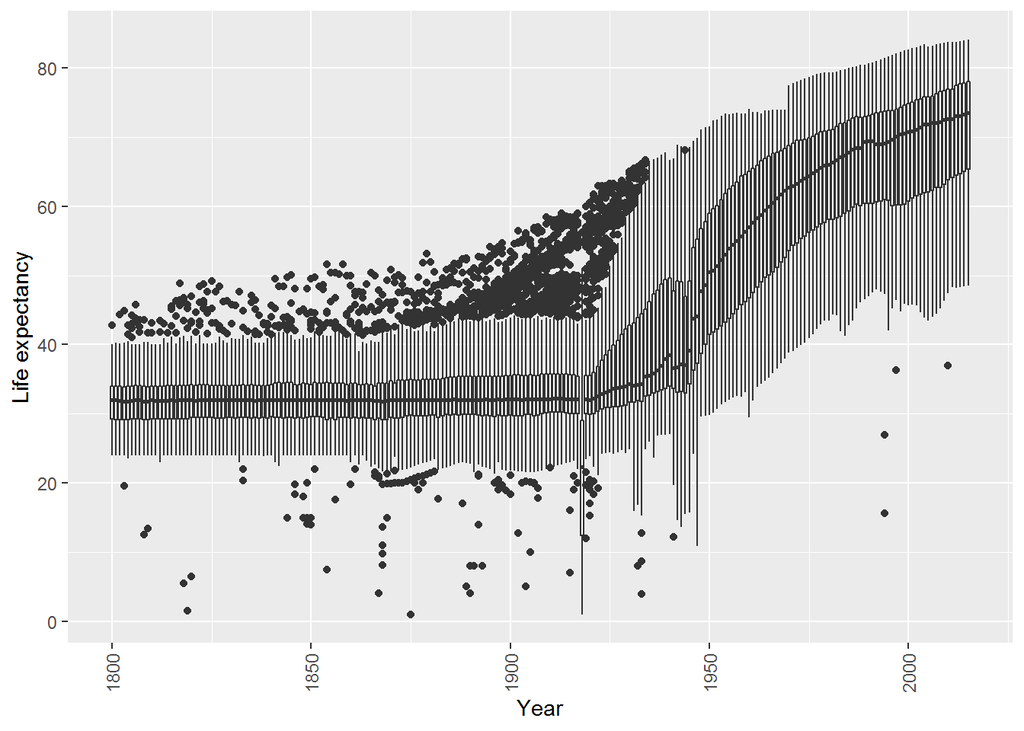

```r
ggplot(data = ds, aes(group=ds$Year, x = Year, y = life)) +
geom_boxplot() + ylab("Life expectancy") + theme(axis.text.x = element_text(angle = 90, vjust = 0.5))
```

##### Analysis : As we can see that income increased over the years. Income increased after 1951

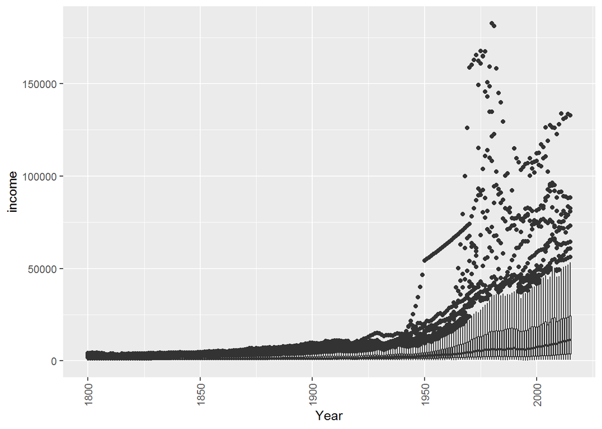

```r
ggplot(data = ds, aes(group=ds$Year, x = Year, y = income)) +
geom_boxplot() + ylab("income") + theme(axis.text.x = element_text(angle = 90, vjust = 0.5))
```

##### Analysis: It makes sense to do Analysis of data from the year 1951 since data before that seems to be distorted

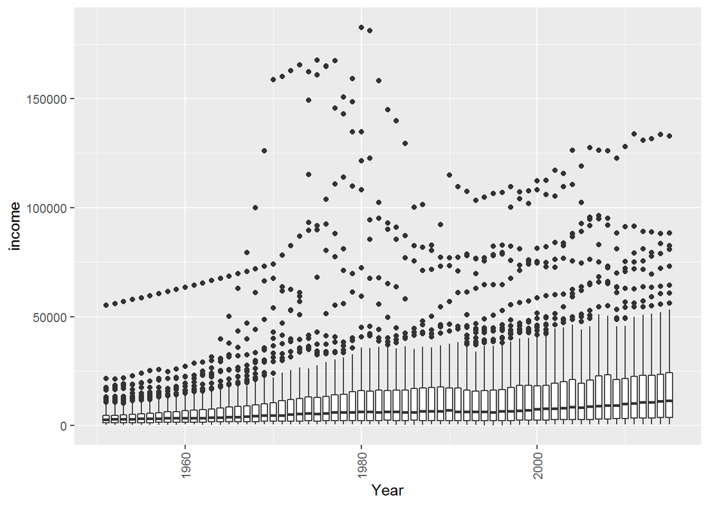

```r
ggplot(data = dsgreater1951, aes(group=dsgreater1951$Year, x = Year, y = income)) +
geom_boxplot() + ylab("income") + theme(axis.text.x = element_text(angle = 90, vjust = 0.5))
```

#### Changing the color

```r
Palette <- c("#E69F01", "#56B4E8", "#009E72", "#F0E441", "#0072B3", "#D55E01")
```

##### Our Analysis :- Here we are comparing data from year 1951 to 2015 since the it appears that the data earlier than it was manually derived from the data from 1951-2015. SO if we plot that daat we can see that Life Expectancy increase for Europe from 1951-2015. But also it increase for other continents as well. Eventhough Europe maintained the lead in 1951.

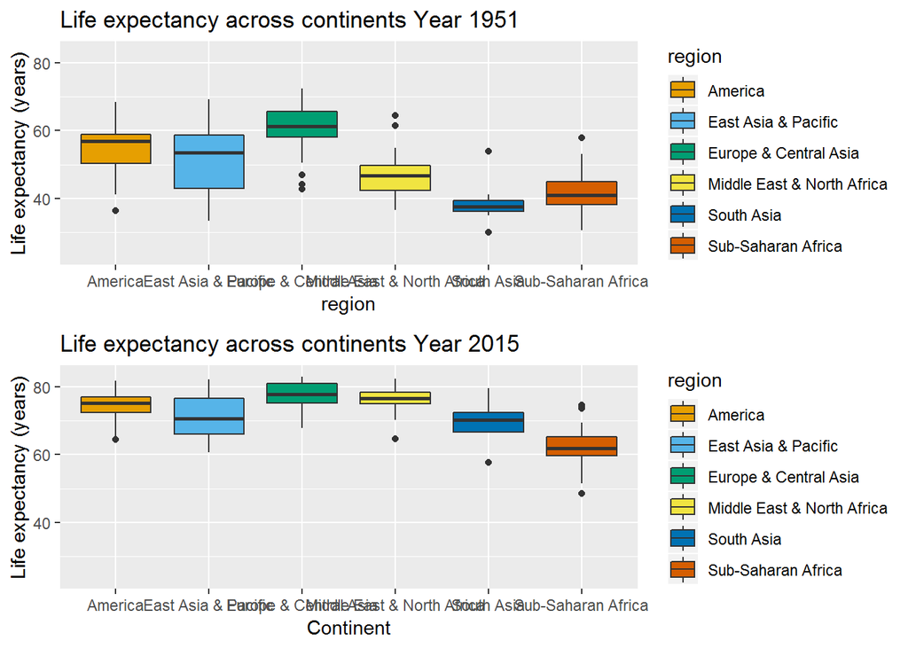

```r
p1 = ggplot(data = ds1951, aes(x = region, y = life )) +
  geom_boxplot(aes(fill = region)) +
  ggtitle("Life expectancy across continents Year 1951") +
  xlab('region') + ylab("Life expectancy (years)") +
  ylim(c(23.39, 83.42)) +
  scale_fill_manual(values= Palette)

p2 = ggplot(data = ds2015, aes(x = region, y = life)) +
  geom_boxplot(aes(fill = region)) +
  ggtitle("Life expectancy across continents Year 2015") +
  xlab('Continent') + ylab("Life expectancy (years)") +
  ylim(c(23.39, 83.42)) +
  scale_fill_manual(values= Palette)

grid.arrange(p1,p2, ncol = 1)
```

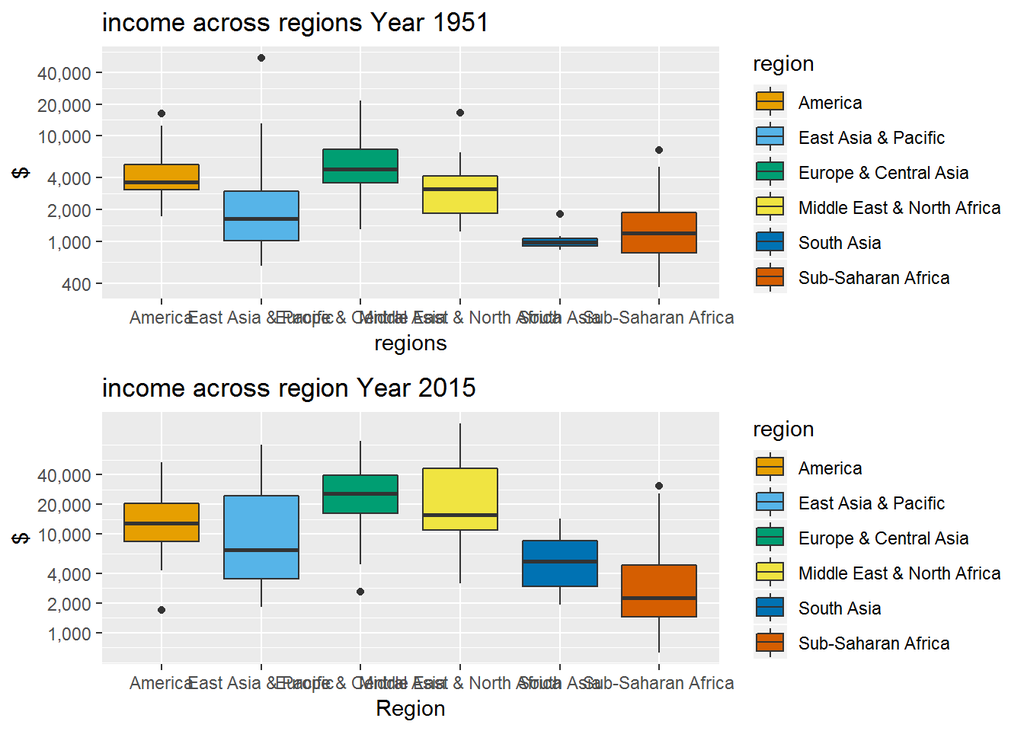

```r
ybreaks = c(200, 400, 1000, 2000, 4000, 10000, 20000, 40000)
p3 = ggplot(data = ds1951, aes(x = region, y = income)) +
  geom_boxplot(aes(fill = region)) +
  ggtitle("income across regions Year 1951") +
  xlab('regions') + ylab("$") +
  scale_y_log10(breaks = ybreaks,
                labels = comma(ybreaks)) +
  scale_fill_manual(values= Palette)

p4 = ggplot(data = ds2015, aes(x = region, y = income)) +
  geom_boxplot(aes(fill = region)) +
  ggtitle("income across region Year 2015") +
  xlab('Region') + ylab("$") +
  scale_y_log10(breaks = ybreaks,
                labels = comma(ybreaks)) +
  scale_fill_manual(values= Palette)

grid.arrange(p3,p4, ncol = 1)
```

##### Our Analysis: The results of the ggplot confirms that our finding from the box plot

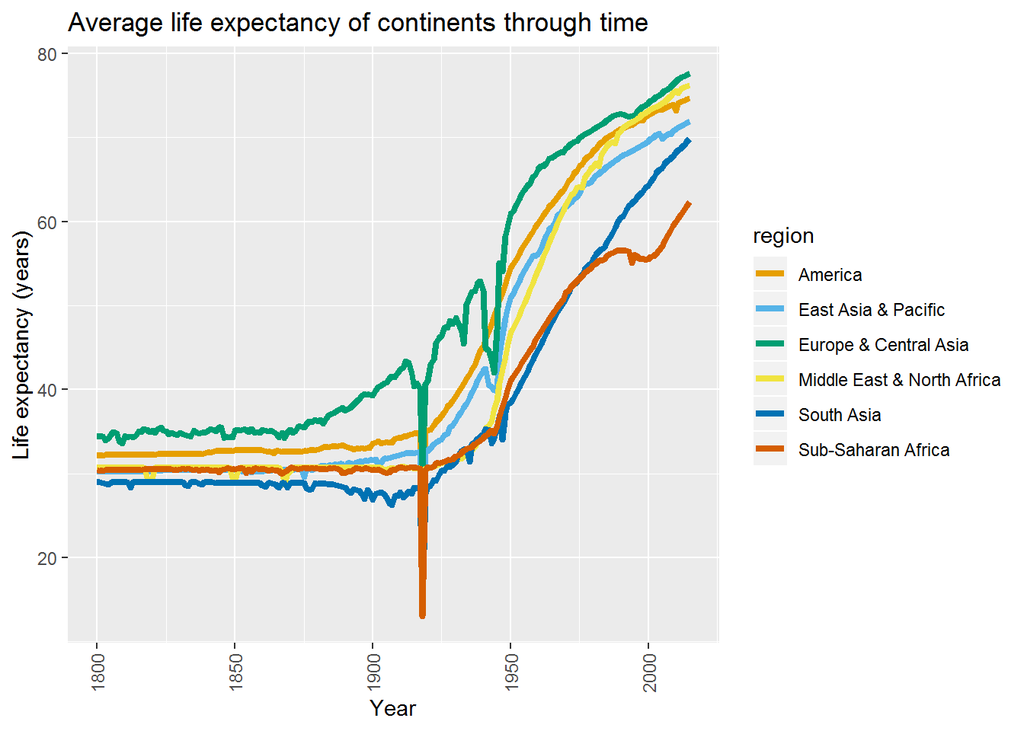

```r
grouped = group_by(ds, Year, region)
ds.byYearContinent = summarise(grouped,
                                   life_mean = mean(life),
                                   income_mean = mean(income))
ggplot(ds.byYearContinent, aes(x = Year, y = life_mean,
                                   colour = region,
                                   group =region)) +
  geom_line(size = 1.5) +
  scale_color_manual(values= Palette) +
  ylab("Life expectancy (years)") +
  ggtitle("Average life expectancy of continents through time") +
  theme(axis.text.x = element_text(angle = 90, vjust = 0.5))
```

##### Our Analysis: The results of the ggplot confirms that our finding from the box plot

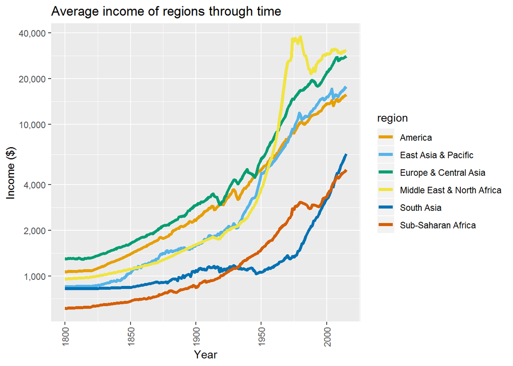

```r
ybreaks = c(200, 400, 1000, 2000, 4000, 10000, 20000, 40000)
ggplot(ds.byYearContinent, aes(x = Year, y = income_mean,
                                   colour = region,
                                   group = region)) +
  geom_line(size = 1.5) +
  scale_color_manual(values= Palette) +
  scale_y_log10(breaks = ybreaks,
                labels = comma(ybreaks)) +
  ylab("Income ($)") +
  ggtitle("Average income of regions through time") +
  theme(axis.text.x = element_text(angle = 90, vjust = 0.5))
```

##### Analysis :Now we go about Finding the Correlation betweeen Life expectancy and income for 1951. This plot depicts that the regions with higher income have higher life expectancy.

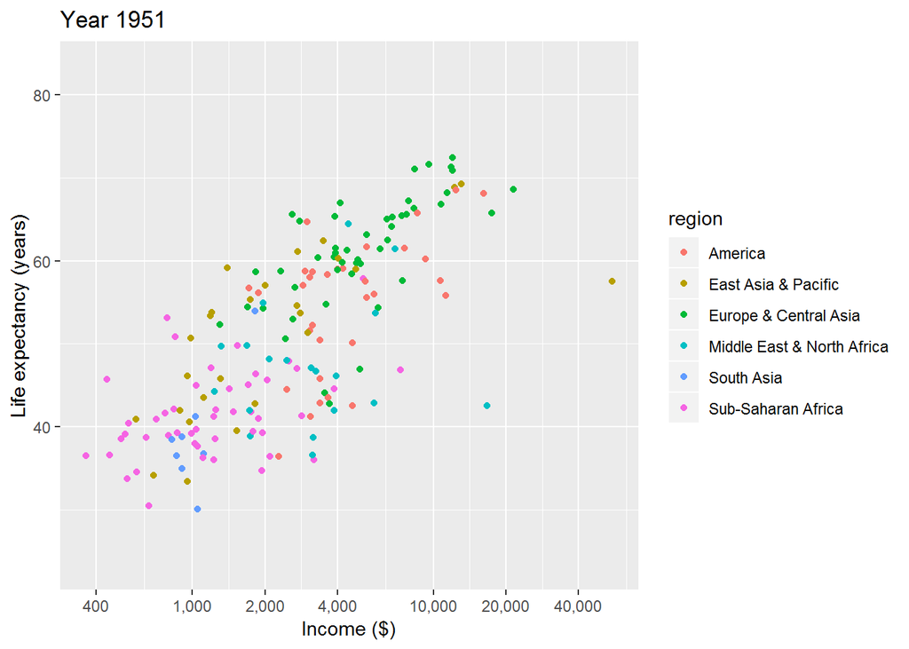

```r
xbreaks = c(200, 400, 1000, 2000, 4000, 10000, 20000, 40000)
ggplot(data = subset(ds, Year == 1951),
       aes(x = income, y = life,col = region)) +
  geom_point() +
  ggtitle("Year 1951") +
  xlab("Income ($)") +
  ylab("Life expectancy (years)") +
  scale_x_log10(breaks = xbreaks,
                labels = comma(xbreaks)) +
  ylim(c(23.39, 83.42))
```

```r
cor(ds$income,ds$life)
```

```
## [1] 0.576409
```

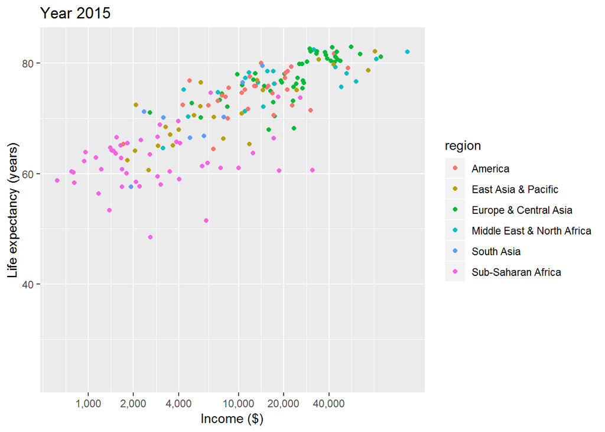

```r
xbreaks = c(200, 400, 1000, 2000, 4000, 10000, 20000, 40000)
ggplot(data = subset(ds, Year == 2015),
       aes(x = income, y = life,col = region)) +
  geom_point() +
  ggtitle("Year 2015") +
  xlab("Income ($)") +
  ylab("Life expectancy (years)") +
  scale_x_log10(breaks = xbreaks,
                labels = comma(xbreaks)) +
  ylim(c(23.39, 83.42))
```

```r
cor(ds$income,ds$life)
```

```
## [1] 0.576409
```

#### Correlation betweeen Life expectancy and income Population of countries taken into account

##### Our Analysis:- The size of the bubble is represnts the size of the Population of the country. American and Europe and Central Asia countries leaded both in terms of life expectancy and income while Sub Sahara African and asian countries lagged behind in 1951.

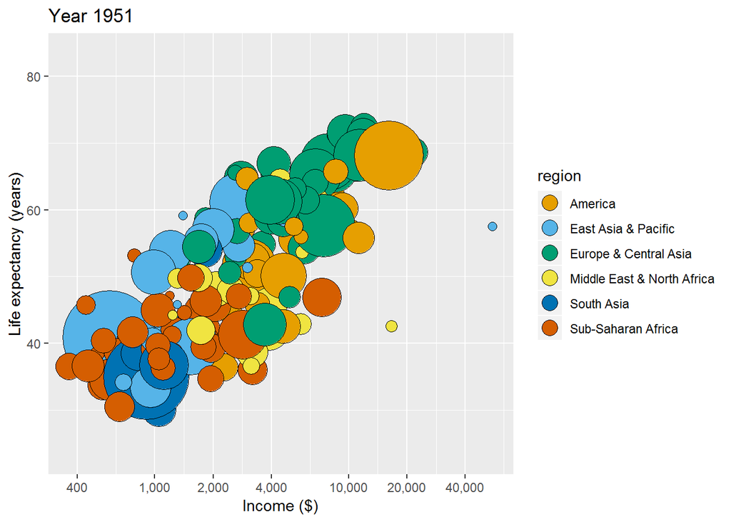

```r
xbreaks = c(200, 400, 1000, 2000, 4000, 10000, 20000, 40000)
ggplot(data = subset(ds, Year == 1951),
       aes(x = income, y = life)) +
  geom_point(aes(fill = region, size = sqrt(population/pi)),
             pch = 21) +
  ggtitle("Year 1951") +
  xlab("Income ($)") +
  ylab("Life expectancy (years)") +
  scale_x_log10(breaks = xbreaks,
                labels = comma(xbreaks)) +
  scale_size_continuous(range=c(1,30)) +
  guides(size = F, fill = guide_legend(override.aes = list(size=5))) +
  scale_fill_manual(values= Palette) +
   ylim(c(23.39, 83.42))
```

##### Our Analysis:- The size of the bubble is represnts the size of the Population of the country.American and Europe and Central Asia countries leaded both in terms of life expectancy and income while middle east and North Africa,East Asia and pacific countries caught up well in 2015.

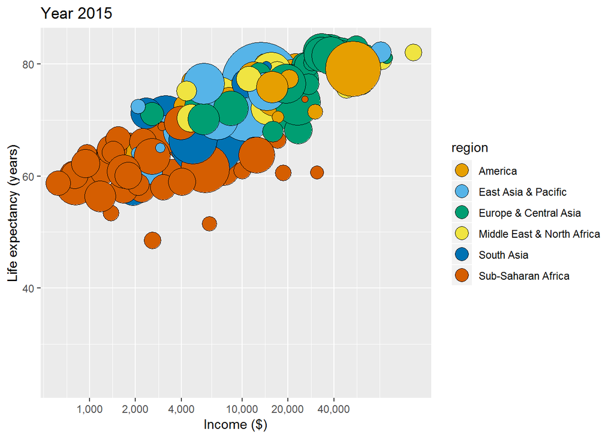

```r
xbreaks = c(200, 400, 1000, 2000, 4000, 10000, 20000, 40000)
ggplot(data = subset(ds, Year == 2015),
       aes(x = income, y = life)) +
  geom_point(aes(fill = region, size = sqrt(population/pi)),
             pch = 21) +
  ggtitle("Year 2015") +
  xlab("Income ($)") +
  ylab("Life expectancy (years)") +
  scale_x_log10(breaks = xbreaks,
                labels = comma(xbreaks)) +
  scale_size_continuous(range=c(1,30)) +
  guides(size = F, fill = guide_legend(override.aes = list(size=5))) +
  scale_fill_manual(values= Palette) +
  ylim(c(23.39, 83.42))
```

##### Analysis:-As we can see that the Life expectancy was leaded by Amercias and Europe and Central Asia. While East and Pacific was close

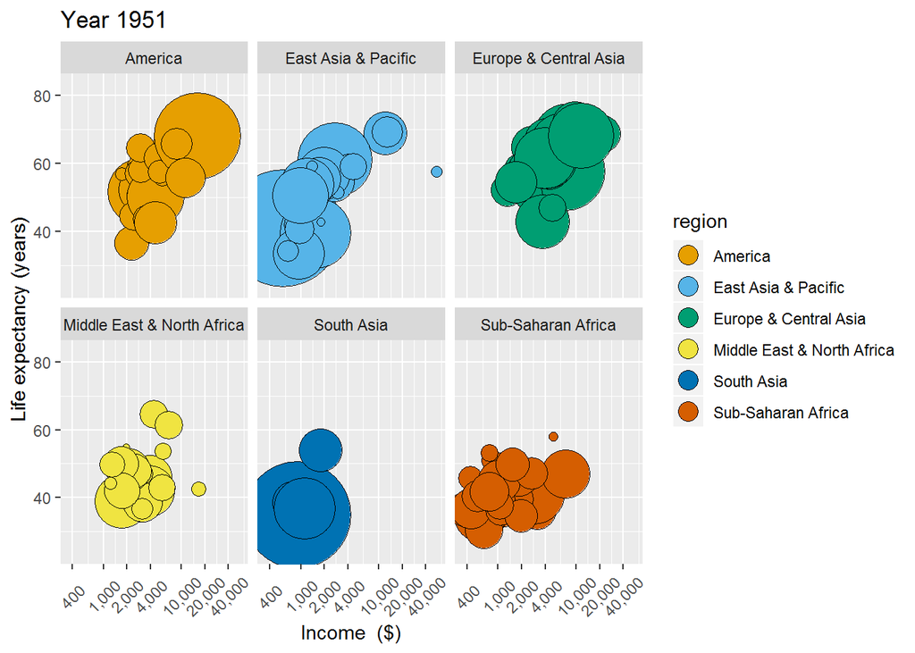

```r
xbreaks = c(200, 400, 1000, 2000, 4000, 10000, 20000, 40000)
ggplot(data = subset(ds, Year == 1951),
       aes(x = income, y = life)) +
  geom_point(aes(fill = region, size = sqrt(population/pi)),
             pch = 21) +
  ggtitle("Year 1951") +
  xlab("Income  ($)") +
  ylab("Life expectancy (years)") +
  scale_x_log10(breaks = xbreaks,
                labels = comma(xbreaks)) +
  scale_size_continuous(range=c(1,30)) +
  guides(size = F, fill = guide_legend(override.aes = list(size=5))) +
  scale_fill_manual(values= Palette) +
  ylim(c(23.39, 83.42)) +
  facet_wrap(~region) +
  theme(axis.text.x = element_text(angle = 45, vjust = 0.5))
```

##### Analysis:-As we can see that the Life expectancy impoved in East Asia and Pacific and Americas and Europe and Central Asia. While East and Pacific was close

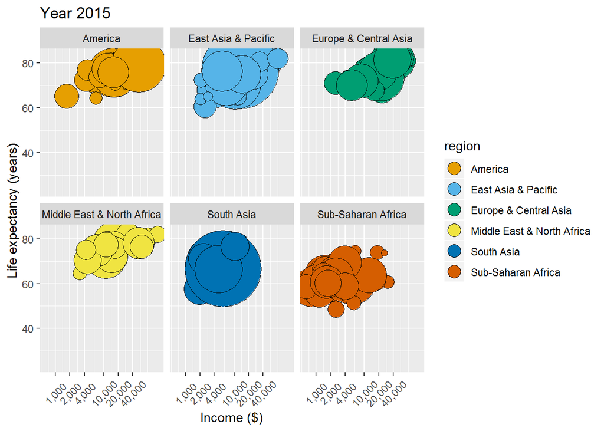

```r
xbreaks = c(200, 400, 1000, 2000, 4000, 10000, 20000, 40000)
ggplot(data = subset(ds, Year == 2015),
       aes(x = income, y = life)) +
  geom_point(aes(fill = region, size = sqrt(population/pi)),
             pch = 21) +
  ggtitle("Year 2015") +
  xlab("Income ($)") +
  ylab("Life expectancy (years)") +
  scale_x_log10(breaks = xbreaks,
                labels = comma(xbreaks)) +
  scale_size_continuous(range=c(1,30)) +
  guides(size = F, fill = guide_legend(override.aes = list(size=5))) +
  scale_fill_manual(values= Palette) +
  ylim(c(23.39, 83.42)) +
  facet_wrap(~region) +
  theme(axis.text.x = element_text(angle = 45, vjust = 0.5))
```

#### First,Calculate a trimmed(trim=0.2) mean of life expectancy for different years

```r
Trm <- 0.2
Trm_meanlifeExp<- ddply(ds,~Year,summarize, tMean = mean(life, trim = Trm))
Trm_meanlifeExp <- arrange(Trm_meanlifeExp, tMean)
```

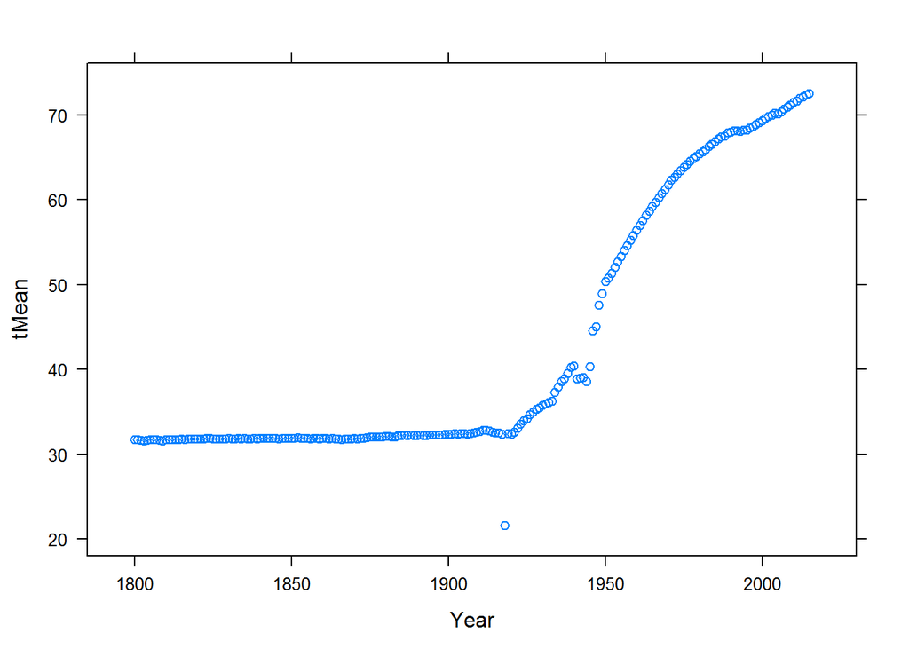

```r
xyplot(tMean~Year,Trm_meanlifeExp)
```

## QUESTION 2 Evaluate the change in life expectancy over a period of time on different regions?

#### First, we will calculate the life expenctancy for different regions over time to a data frame.

```r
LifeExpectancy_cont <- ddply(ds,~Year+region,summarize,avglifeExp=mean(life))
```

#### Then next we will plot the data using strippplot

[figure not shown]

```r
stripplot(avglifeExp~Year,LifeExpectancy_cont,group=region,auto.key=TRUE,grid="h", jitter.data = TRUE)
```

##### Our Analysis : We can see that there is an increase in avgerage life expecatncy over time for different regions. Except there is slight dip in the Sub-Saharan Africa.

## Question 3 Show the maximum and minimum of income for all regions.Use year 2008 as reference

```r
## Getting the subset data from 2008
subset2008= subset(ds,Year==2008)
```

```r
##Find the min and max income for all regions in 2008
income_cont <- ddply(subset2008,~region,summarize,maxGDP=max(income),minGDP=min(income))
income_cont
```

```
##                       region maxGDP minGDP
## 1                    America  50384   1600
## 2        East Asia & Pacific  72351   1486
## 3      Europe & Central Asia  95001   2001
## 4 Middle East & North Africa 126076   2502
## 5                 South Asia  12029   1311
## 6         Sub-Saharan Africa  40143    588
```

##### Our Analysis: We can see that Maximum income stands for Middle East and North Africa region. Closely followed by Europe & Central Asia

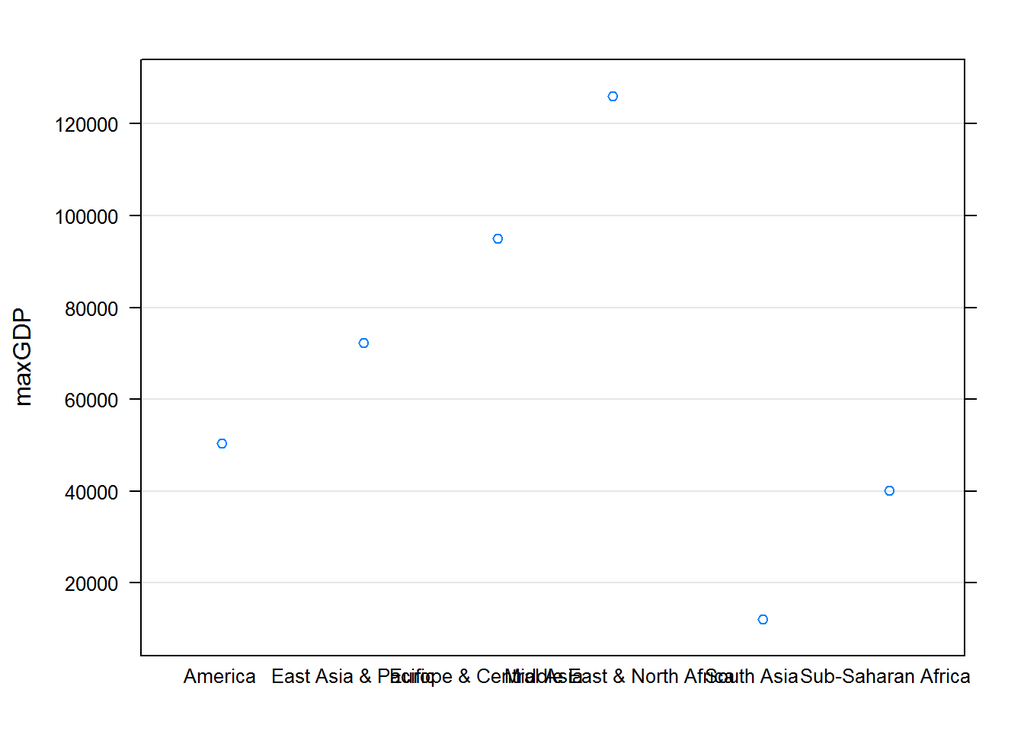

```r
##Plot maximum income with stripplot
stripplot(maxGDP~region,income_cont,grid="h", jitter.data = TRUE)
```

##### Our Analysis:We can see that minimum income stands for Sub-Saharan Africa regions. Closely followed by South Asia

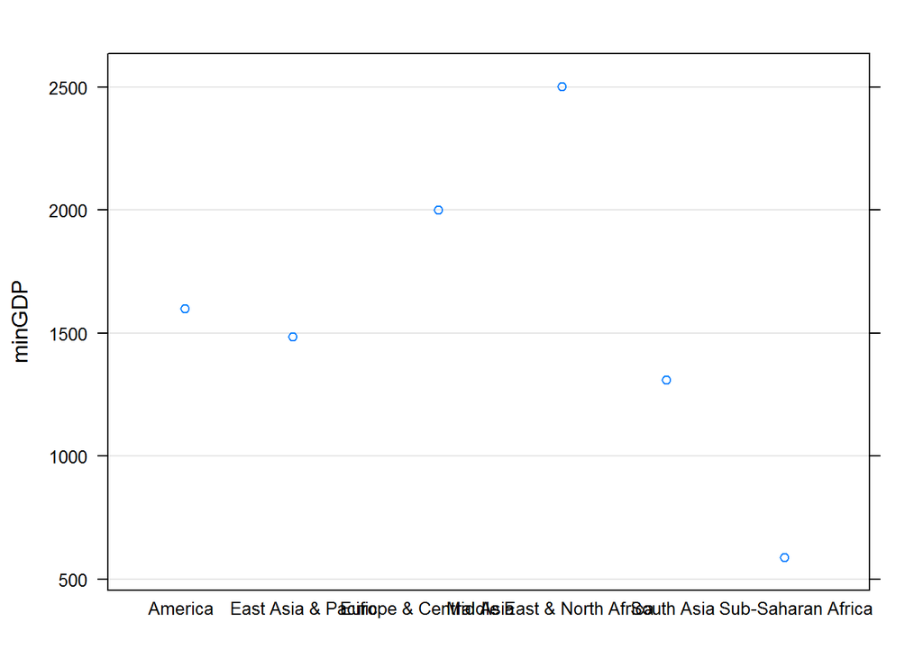

```r
##Plot min income with stripplot
stripplot(minGDP~region,income_cont,grid="h", jitter.data = TRUE)
```

## QUESTION 4 Analyse the spread of income within the regions.

##### Our Analysis: As we analyse the spread for each regions we see that middle east and North Africa in income.South Asia has been steady, WHile east asia and pacific there was major turbulence in a certain era. income Europe and Central Asia grew steadily.

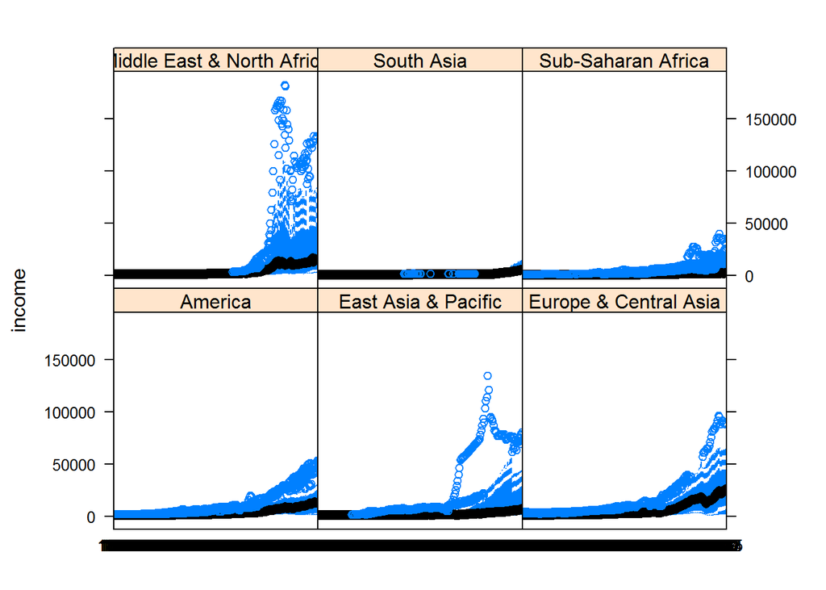

```r
bwplot(income~as.factor(Year) | region,ds)
```

## QUESTION 5 Show the number and/or proportion of countries with low life expectancy over time by region.

```r
##Lets select the base of low lifeExp as 60. We can select any random number
lowlifeExpectancy=60
```

#### Calculate he proportion of countries with low life expectancy over time by region

```r
## Caluclating the  proportion of countries with low life expectancy over time by region
ProportionlowlifeExp <- ddply(ds, ~ region + Year, function(x) c(
     lowlifeExpectancy = sum(x$life <= lowlifeExpectancy)/nrow(x)) )
```

##### Our Analysis:- Shows that Sub-Saharan Africa has the lowest life expectancy

[figure not shown]

```r
##Plottig the data with stripplot, also we are changing the default y-axis to display from 0% to 100%
stripplot(lowlifeExpectancy~Year,ProportionlowlifeExp,group=region,auto.key=TRUE,ylim=c(0,100),ylab="percentage of Low LifeExp country")
```

```r
##Fitting a linear model
yearMin <- min(ds$Year)
jFunc <- function(x) {
   jiFit <- lm(life ~ I(Year - yearMin), x)
   jiCoef <- coef(jiFit)
   names(jiCoef) <- NULL
   return(c(intercept = jiCoef[1],
            slope = jiCoef[2],
            maxResid = max(abs(resid(jiFit)))/summary(jiFit)$sigma))
  }
lm <- ddply(ds, ~ Country, jFunc)
lm
```

```
##                    Country intercept      slope maxResid
## 1              Afghanistan 20.895865 0.11120053 4.596109
## 2                  Albania 23.359250 0.21320679 3.390593
## 3                  Algeria 15.112726 0.22757321 2.119272
## 4                  Andorra 52.623990 0.14835646 2.138955
## 5                   Angola 18.694878 0.14383058 4.257374
## 6      Antigua and Barbuda 21.146052 0.23099948 3.384651
## 7                Argentina 21.928885 0.24710349 2.177685
## 8                  Armenia 22.604372 0.21236909 4.139232
## 9                    Aruba 22.342892 0.22754763 3.258773
## 10               Australia 24.192471 0.27706465 2.286387
## 11                 Austria 22.608563 0.25844602 4.602341
## 12              Azerbaijan 17.237482 0.22371591 3.413360
## 13                 Bahamas 24.366461 0.20168060 3.706035
## 14                 Bahrain 16.822605 0.23210348 1.925776
```

[output cut: 169 more lines]

##### Our Analysis: The life expectancy increase with years

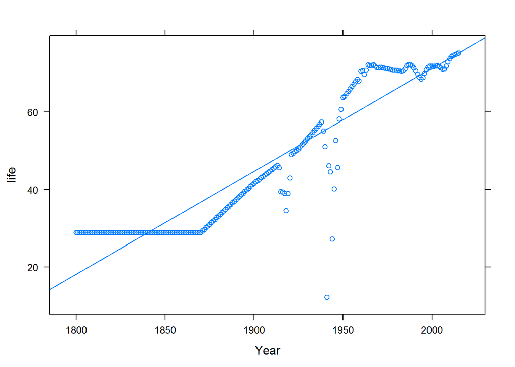

```r
##Then plotting x its data
cont_interest <- lm[which.max(lm$maxResid),]
xyplot(life ~ Year , ds, subset = Country %in% cont_interest$Country, type = c("p", "r"))
```

### Summary/Conclusion: Overall we can conclude that Life expectancy increases over the years. However it is not conclusive that the factors effecting life expectancy are income,population. There can be other factors effecting the life expectancy as well and more research needs to be done to find the reason for increase in life expectancy.Having said that income and population do provide us with significant insights to draw conclusion.As we summarize this we also see that life expectancy is maximum in Europe and Americas and Central Asia. And we see that Sub-Saharan Africa has been the lowest in terms of Life Expectancy. But again there are various factors that effect these stats. Income and population surely plays a role and we cannot deny that but more substantial data is needed to reach to any conclusion